# Proyecto Final (parte 3)

Michelle Audirac

12/10/2017

```r
total <- readRDS('../data/total_prep.RDS')
train <- readRDS('../data/train_prep.RDS')
test <- readRDS('../data/test_prep.RDS')
```

## Exploración multivariada

En esta sección hacemos la exploración multivariada de los datasets.

### Visit Number + ScanCount

**total_Visits**

```r
total_Visits <- total %>%
  select(VisitNumber, Weekday, ScanCount) %>%
  group_by(VisitNumber, Weekday) %>%
  summarize(VisitRows = n(), VisitItems = sum(ScanCount))
```

- Cuál es el resumen del número de items comprados por `VisitNumber` en el dataset `total`?

```r
summary(total_Visits$VisitItems)
```

```
##    Min. 1st Qu.  Median    Mean 3rd Qu.    Max.
##    -104       4       8      15      18     622
```

### VisitNumber + ScanCode + Weekday

- Cuántas visitas hay por `Weekday` en el dataset `total`?

```r
table(total_Visits$Weekday)
```

```
##
##    Friday    Monday  Saturday    Sunday  Thursday   Tuesday Wednesday
##     15234     12027     16904     17124     11243     11530     11612
```

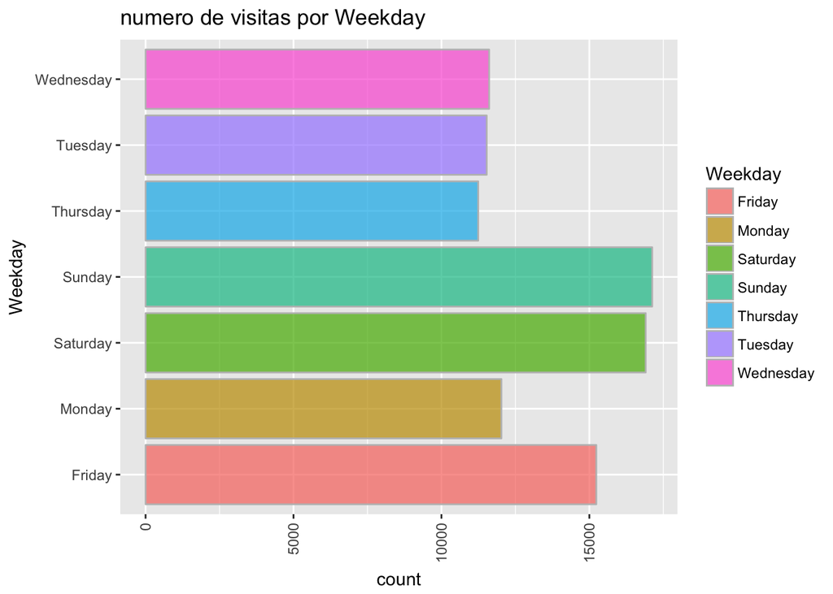

```r
total_Visits %>%
  ggplot(aes(Weekday, fill = Weekday)) +
  geom_bar(colour = 'grey', alpha = 0.7) +
  theme(axis.text.x = element_text(angle = 90, vjust = 0.5, hjust=1)) +
  labs(title = "numero de visitas por Weekday", x = "Weekday", y = "count") +
  coord_flip()
```

- Cuántos items se compran por visita por `Weekday` en el dataset `total`?

Filtramos aquellas visitas con más de 125 items.

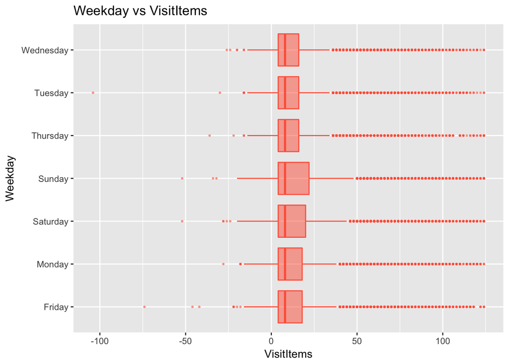

```r
total_Visits %>%
  filter(VisitItems < 125) %>%
  ggplot(aes(x = Weekday, y = VisitItems)) +
  geom_boxplot(outlier.size = 0.5, fill = 'tomato', colour = 'tomato', alpha = 0.5) +
  ggtitle("Weekday vs VisitItems") +
  coord_flip()
```

### VisitNumber + ScanCode + TripType

**train_Visits**

```r
train_Visits <- train %>%
  select(TripType, VisitNumber, Weekday, ScanCount) %>%
  group_by(TripType, VisitNumber, Weekday) %>%
  summarize(VisitRows = n(), VisitItems = sum(ScanCount))
```

- Cuántas visitas hay por `TripType` en el dataset `train`?

```r
table(train_Visits$TripType)
```

```
##
##     3     4     5     6     7     8     9    12    14    15    18    19
##  3643   346  4593  1277  5752 12161  9464   269     4   978   549   375
##    20    21    22    23    24    25    26    27    28    29    30    31
##   637   641   928   139  2609  3698   503   785   492   433  1081   594
##    32    33    34    35    36    37    38    39    40    41    42    43
##  1984  1315   719  2030  3005  2788  2912  9896  6130   583  1858   872
##    44   999
##  1187  8444
```

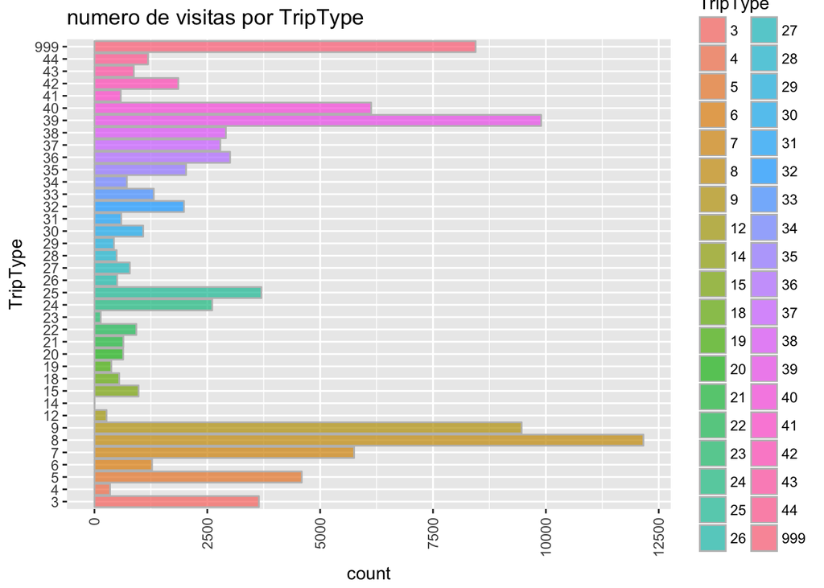

```r
train_Visits %>%
  ggplot(aes(x = TripType, fill = TripType)) +
  geom_bar(colour = 'grey', alpha = 0.7) +
  theme(axis.text.x = element_text(angle = 90, vjust = 0.5, hjust=1)) +
  labs(title = "numero de visitas por TripType", x = "TripType", y = "count") +
  coord_flip()
```

Hay 4 visitas en el `TripType` 14.

- Cuántos items se compran por visita por `TripType` en el dataset `train`?

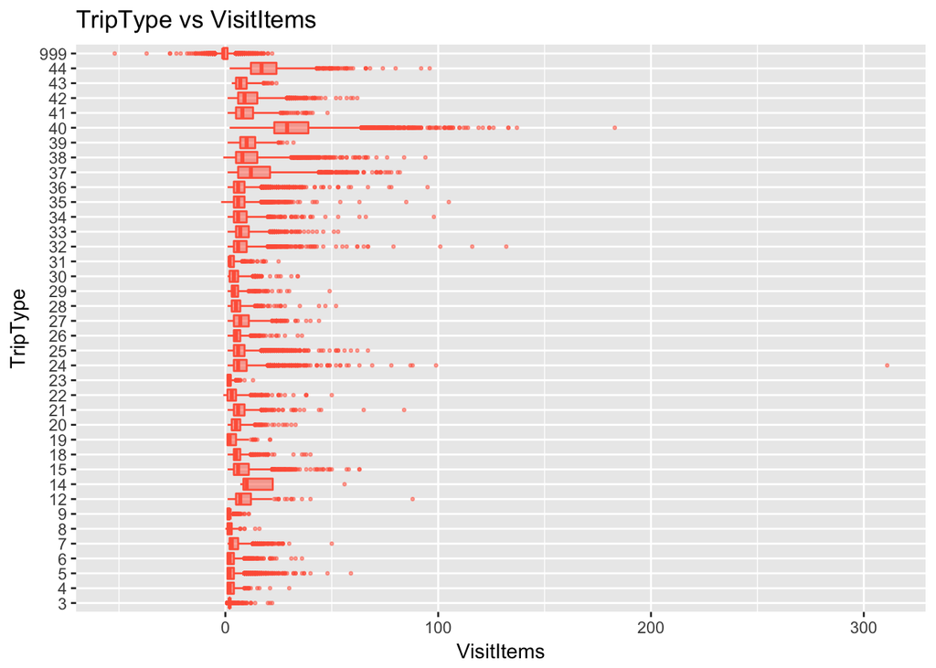

```r
train_Visits %>%
  ggplot(aes(x = TripType, y = VisitItems)) +
  geom_boxplot(outlier.size = 0.5, fill = 'tomato', colour = 'tomato', alpha = 0.5) +
  coord_flip() +
  ggtitle("TripType vs VisitItems")
```

Concluimos que el número de items por visita distingue entre distintos `TripType`s.

### VisitNumber + ScanCode + DepartmentDescription

**total_Depts**

```r
total_Depts <- total %>%
  select(VisitNumber, Weekday, ScanCount, DepartmentDescription) %>%
  group_by(VisitNumber, Weekday, DepartmentDescription) %>%
  summarize(DeptRows = n(), DeptItems = sum(ScanCount))
```

- Cuántas visitas hay por Departamento en el dataset `total`?

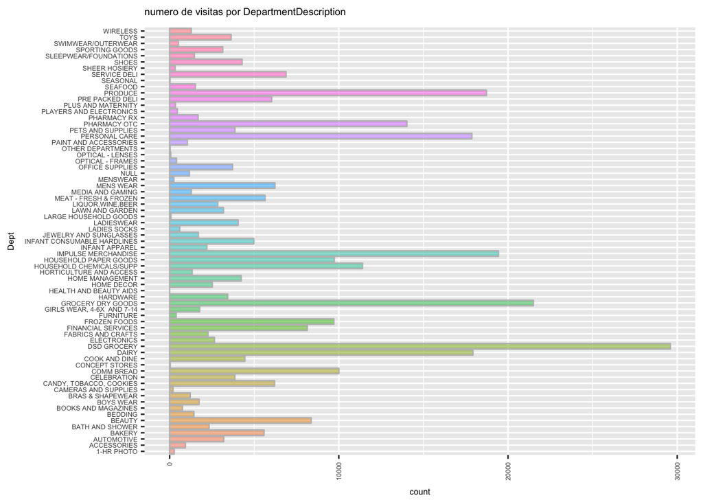

```r
total_Depts %>%
  group_by(DepartmentDescription) %>%
  summarize(n = n_distinct(VisitNumber)) %>%
  ggplot(aes(x = DepartmentDescription, y = n, fill = DepartmentDescription)) +
  geom_bar(stat = 'identity', colour = 'grey', alpha = 0.5) +
  coord_flip() +
  theme(axis.text.x = element_text(angle = 90, vjust = 0.5, hjust=1)) +
  theme(text = element_text(size = 6)) +
  labs(title = "numero de visitas por DepartmentDescription", x = "Dept", y = "count") +
  theme(legend.position="none")
```

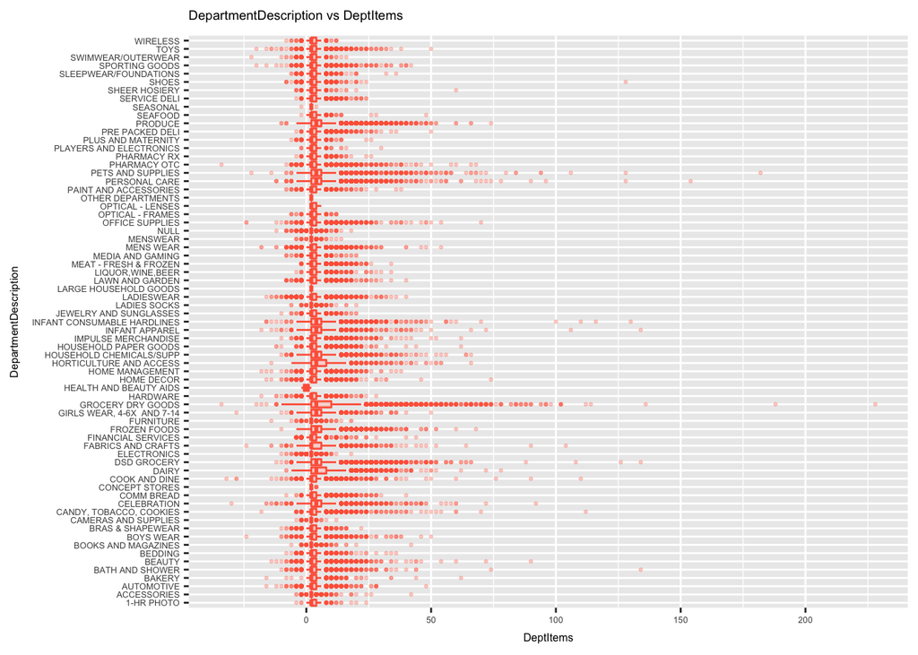

```r
total_Depts %>%
  ggplot(aes(x = DepartmentDescription, y = DeptItems)) +
  geom_boxplot(outlier.size = 0.5, fill = 'tomato', colour = 'tomato', alpha = 0.25) +
  coord_flip() +
  ggtitle("DepartmentDescription vs DeptItems") +
  theme(text = element_text(size = 6))
```

- En cuántos Departamentos se compra en cada visita en el dataset `total`?

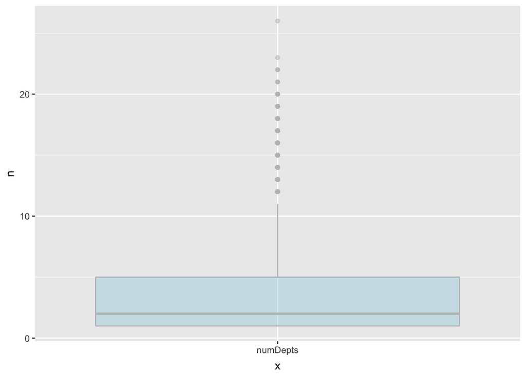

```r
total_Depts %>%
  group_by(VisitNumber) %>%
  summarize(n = n_distinct(DepartmentDescription)) %>%
  ggplot(aes(x = 'numDepts', y = n)) +
  geom_boxplot(fill = 'lightblue', colour = 'grey', alpha = 0.5)
```

### VisitNumber + ScanCode + Weekday + TripType

- Obtenemos la distribución de visitas por `Weekday` para cada `TripType`

Cada renglón representa la distribución de cada TripType.

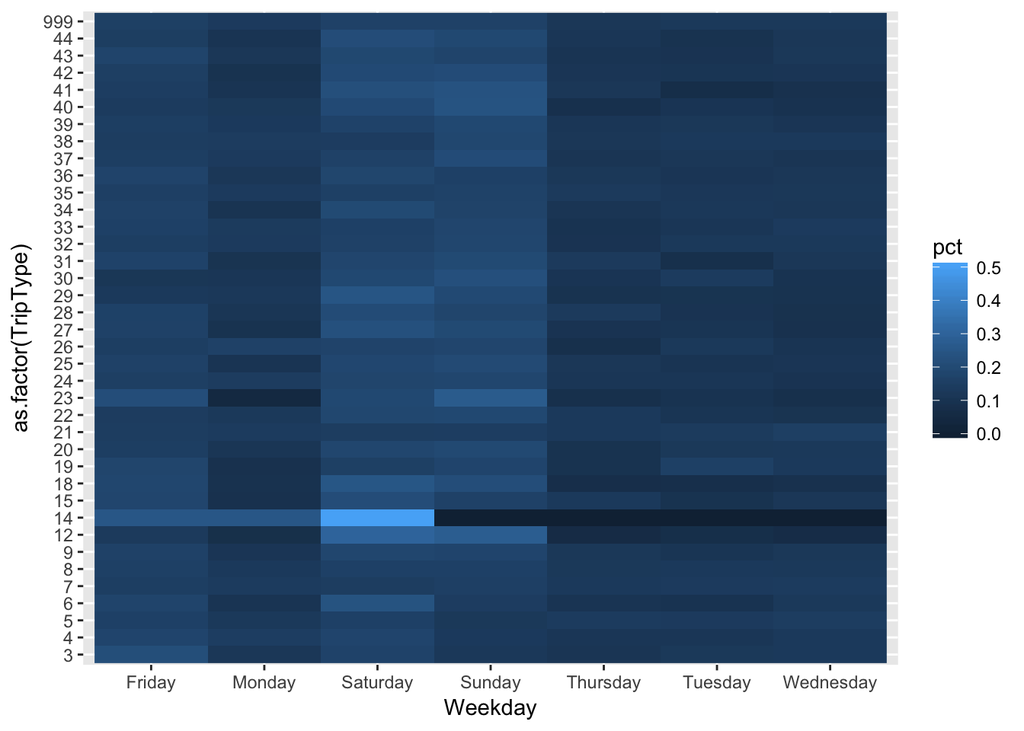

```r
tt <- as.matrix(table(train_Visits$TripType, train_Visits$Weekday))
tt_TripType <- tt / apply(tt, 1, sum)
tt_TripType <- melt(tt_TripType)
colnames(tt_TripType) <- c('TripType', 'Weekday', 'pct')
ggplot(tt_TripType, aes(x = Weekday, y = as.factor(TripType), fill = pct)) +
  geom_raster()
```

- Obtenemos la distribución de visitas por `TripType` para cada `Weekday`

Cada columna representa la distribución de cada Weekday.

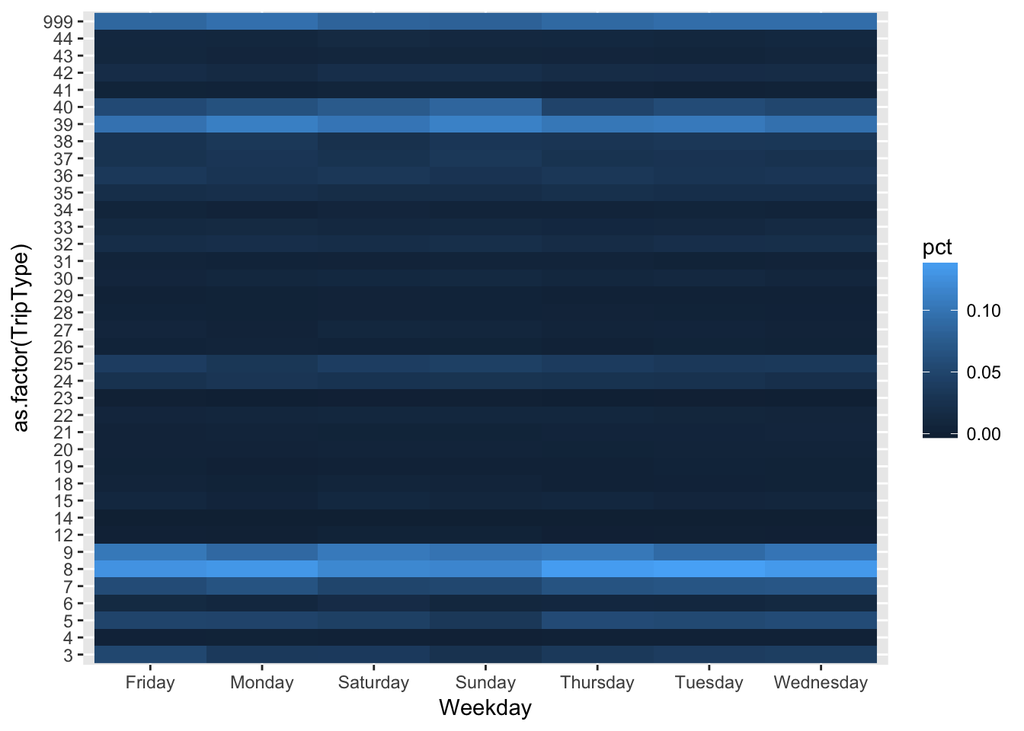

```r
tt <- as.matrix(table(train_Visits$Weekday, train_Visits$TripType))
tt_Weekday <- tt / apply(tt, 1, sum)
tt_Weekday <- melt(tt_Weekday)
colnames(tt_Weekday) <- c('Weekday', 'TripType', 'pct')
ggplot(tt_Weekday, aes(x = Weekday, y = as.factor(TripType), fill = pct)) +
  geom_raster()
```

Concluimos que `Weekday` no distingue entre distintos `TripType`s.

### DepartmentDescription + TripType

- Obtenemos la distribución de observaciones por `TripType` para cada `DepartmentDescription`

Cada columna representa la distribución de cada `DepartmentDescription`.

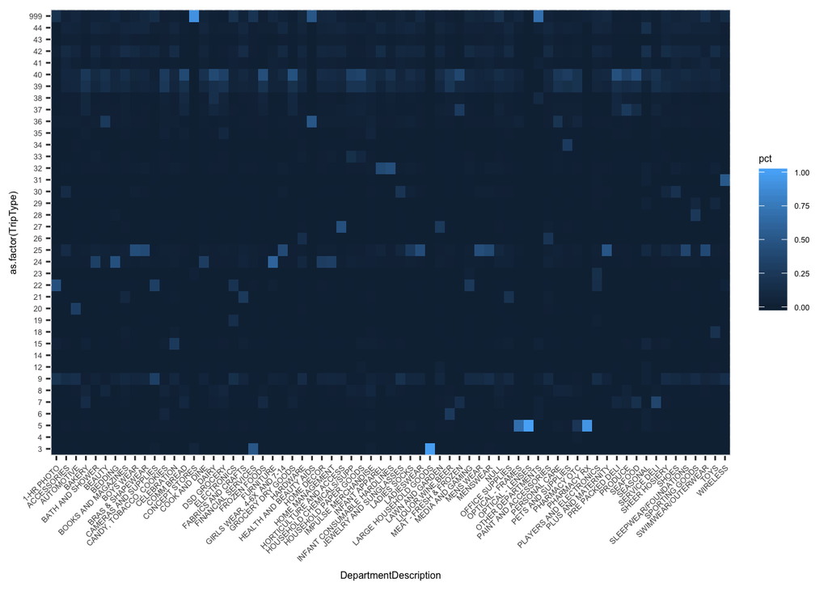

```r
tt <- as.matrix(table(train$DepartmentDescription, train$TripType))
tt <- tt / apply(tt, 1, sum)
tt <- melt(tt)
colnames(tt) <- c('DepartmentDescription', 'TripType', 'pct')

ggplot(tt, aes(x = DepartmentDescription, y = as.factor(TripType), fill = pct)) +
  geom_raster() +
  theme(axis.text.x = element_text(angle = 45, hjust=1)) +
  theme(text = element_text(size = 6))
```

- Obtenemos la distribución de observaciones por `DepartmentDescription` para cada `TripType`

Cada renglón representa la distribución de cada TripType.

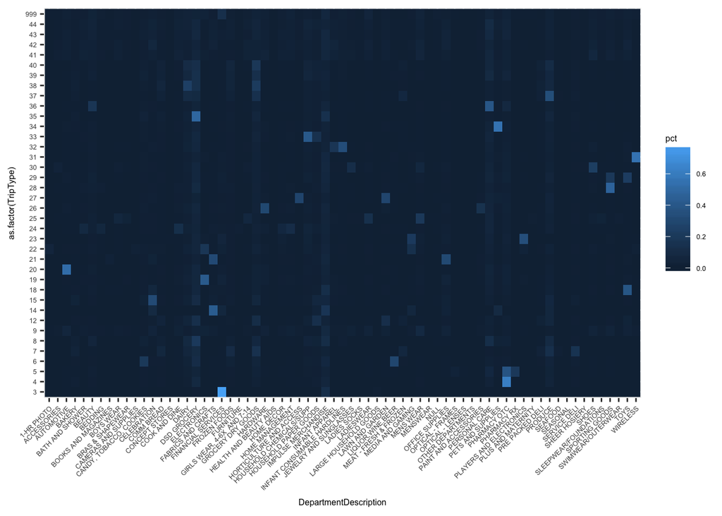

```r
tt <- as.matrix(table(train$TripType, train$DepartmentDescription))
tt_TripType <- tt / apply(tt, 1, sum)
tt_TripType <- melt(tt_TripType)
colnames(tt_TripType) <- c('TripType', 'DepartmentDescription', 'pct')

ggplot(tt_TripType, aes(x = DepartmentDescription, y = as.factor(TripType), fill = pct)) +
  geom_raster()  +
  theme(axis.text.x = element_text(angle = 45, hjust=1)) +
  theme(text = element_text(size = 6))
```

Podemos ver que:

- las observaciones tipo 3 se concentra en *Financial Services*
- las observaciones tipo 14 se concentran en *Fabrics and Crafts*

Concluimos que `DepartmentDescription` distingue entre `TripTypes`